# Lecture 11: Simulating Data

Nick Huntington-Klein

February 12, 2019

## Recap

- Up to now, we’ve been looking at how to manipulate objects in R
- And how to analyze data in R
- Looking at the distributions of those variables
- As well as how two variables relate to each other - dependence, correlation, explanation

## And now!

- What we’ll be moving into soon is how to use these tools so that we can take data and actually *learn things*
- Today we’re going to get ready for that
- How?
- We’re going to *learn some fake things*
- Via simulation, i.e. creating fake data

## Simulation

- Why do this? Why not just use real data?
- Because with real data, *we don’t know what the right answer is*
- So if we do some method, and it gives us an answer, how do we know we did the method right?
- Simulation lets us *know the right answer* so we can check whether or not we *get* that right answer
- And if we do, we know the method works (at least in our fake scenario), so now we can apply it to some real data

## The purpose of data analysis

- When it comes down to it, *what is the purpose of data analysis*? Why do we work with data?
- When we work with data, we have this idea that there exists a *true model*
- The *true model* is the way the world actually works!
- But we don’t know what that true model is

## The purpose of data analysis

- So that’s where the data comes in
- The true model is what *generated the data* (the ‘data generating process’)
- So by looking at the data, and incorporating what we *think* we know about the true model, we’re trying to work backwards to figure out what it is that *generated* that data - and that’s the true model!
- With simulation, *we know* what generated the data and what the true model is. So we know the right answer and can check how close we get.

## Example

- We’ve covered this example before
- Let’s generate 501 coin flips
- The *true model* will be that this will generate heads half the time and tails half the time

```r
coins <- sample(c("Heads","Tails"),501,replace=T)
```

## Example

- Now let’s take that data as given and analyze it in our standard way!
- The proportion of heads is `mean(coins=='Heads') =`0.493014
- And we can look at the distribution, as we would:

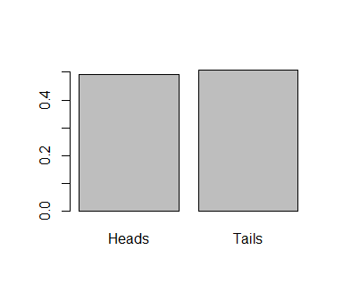

```r
barplot(prop.table(table(coins)))
```

## Example

- So what’s our conclusion?
- We’d come to the conclusion that the *true model* generates heads 0.493014 of the time
- .500 is correct, so pretty close! But not exact. Did this whole thing work or not?
- What if it *always* errs on the same side? Then it’s not a good method at all!

## Simulation in a Loop

- We can go a step further by doing this simulation *over and over again* in a loop!
- This will let us tell whether our method gets it right on average
- And, when it’s wrong, how wrong it is!

## Simulation in a Loop

```r
#A blank vector to hold our results
propHeads <- c()

#Let's run this simulation 2000 times
for (i in 1:2000) {
  #Re-create data using the true model
  coinsdraw <- sample(c("Heads","Tails"),501,replace=T)
  #Re-perform our analysis
  result <- mean(coinsdraw=="Heads")
  #And store the result
  propHeads[i] <- result
}

#Let's see what we get on average
stargazer(as.data.frame(propHeads),type='text')
```

```
##
## ============================================================
## Statistic   N   Mean  St. Dev.  Min  Pctl(25) Pctl(75)  Max
## ------------------------------------------------------------
## propHeads 2,000 0.500  0.022   0.427  0.485    0.515   0.589
## ------------------------------------------------------------
```

## Simulation in a Loop

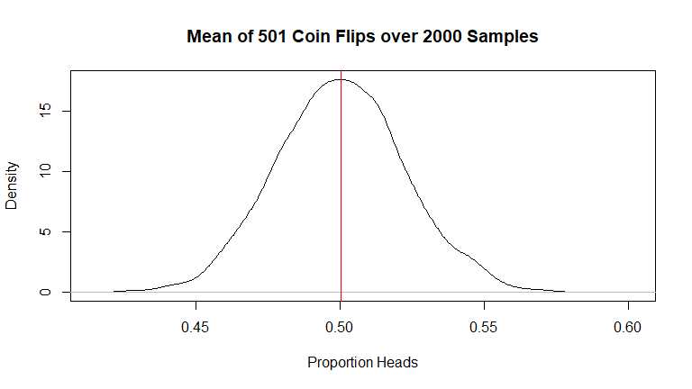

```r
#And let's look at the distribution of our findings
plot(density(propHeads),xlab="Proportion Heads",main="Mean of 501 Coin Flips over 2000 Samples")
abline(v=mean(propHeads),col='red')
```

## Simulation in a Loop

- Now that’s pretty exact!
- What are we learning here?
- The method that we used (simply taking the proportion of heads) will, on average, give us the right answer (.5). Good! Now, if we’re interested in a similar case in the real world, we can apply this method.
- Keeping in mind that in any given sample that we actually observe, it might be a little off.

## Now Imagine

- Imagine we *didn’t* know the answer was .5. What would have happened?
- Wonder “what proportion of the time will a coin be heads?” (what is the true model?)
- Collect data on coin flips
- Perform our analysis method - take proportion of heads, and get 0.493014
- Come to the conclusion that the *true model* is that the coin produces heads 0.493014 of the time.
- We wouldn’t be dead on, but on average we’d be right!

## Generating Other Kinds of Data

- We can use `sample()` as before to pick random data from different categories like Heads and Tails, or integers (say, `1:10`)
- R also has a whole buncha functions to generate random data from other kinds of distributions. See `help(Distributions)`.
- We will focus on two:
- The *uniform* distribution assigns equal probablity to each value in its range (default 0 to 1)
- The *normal* distribution is a bell curve - observations near the mean are very common, observations far away from the mean very rare

## Generating uniform data

- `runif(thismanyobs,min,max)` will draw `thismanyobs` observations from the range of `min` to `max`.
- `runif(thismanyobs)` will assume `min=0` and `max=1`

```r
uniformdata <- runif(5)
uniformdata
```

```
## [1] 0.1267818 0.8207126 0.2619525 0.4291249 0.1961915
```

## Generating Uniform Data

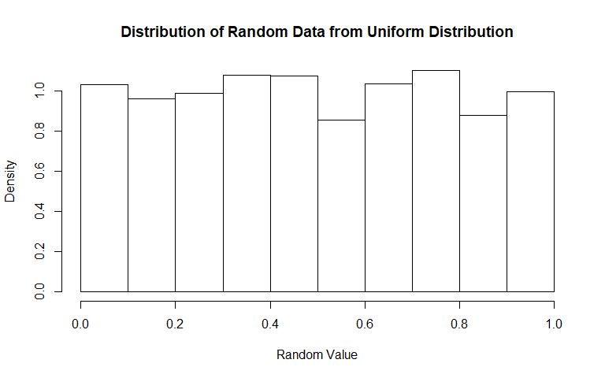

```r
uniformdata <- runif(2000)
hist(uniformdata,xlab="Random Value",main="Distribution of Random Data from Uniform Distribution",probability=TRUE)
```

## Generating Uniform Data

- Good for variables that should be bounded - “percent male” can only be 0-1
- Gives even probability of getting each value

## Generating Normal data

- `rnorm(thismanyobs,mean,sd)` will draw `thismanyobs` observations from a normal distribution with mean `mean` and standard deviation `sd`
- `rnorm(thismanyobs)` will assume `mean=0` and `sd=1`

```r
normaldata <- rnorm(5)
normaldata
```

```
## [1] -2.2990547  0.1119890 -0.3365734  2.2590853 -0.7877652
```

## Generating Normal Data

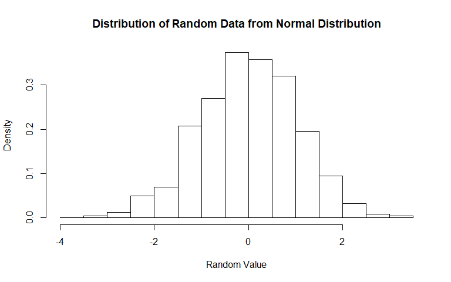

```r
normaldata <- rnorm(2000)
hist(normaldata,xlab="Random Value",main="Distribution of Random Data from Normal Distribution",probability=TRUE)
```

## Generating Normal Data

- Good for many ‘real-worldy’ variables - height, intellect, log income, education level
- Especially when those distributions tend to be tightly packed around the mean!
- Less good for variables with huge huge outliers, like stock market returns

## Let’s Simulate!

- Let’s expand our use of simulation to simulate the relationship between *two* variables
- We can do this by using one variable to build another (note that I draw 400 random genders, and add to them 400 random normals)

```r
# 400 people equally likely to be M or F
simdata <- tibble(gender = sample(c("Male","Female"),400,replace=T)) %>%
  # Height is normally distributed with mean 5.5 and sd 1
  #and men are .9 of a foot taller
  mutate(heightft = .9*(gender == "Male")+rnorm(400,5.5))
simdata %>% group_by(gender) %>% summarize(height = mean(heightft))
```

```
## # A tibble: 2 x 2
##   gender height
##   <chr>   <dbl>
## 1 Female   5.45
## 2 Male     6.42
```

## Two Variable Simulation

- We get in our simulation that men are on average 0.9730581 taller than women.
- The true data-generating process is that heightft is a normal variable with mean 5.5, plus .9 if you’re male

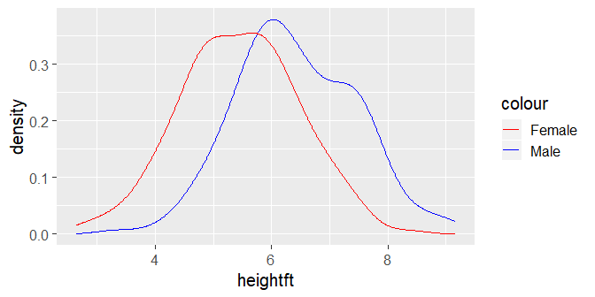

## Two variable simulation

- So does checking for the difference of means give us back the difference in height from the data-generating process? Let’s loop!

```r
heightdiff <- c()
for (i in 1:2500) {
  simdata <- tibble(gender = sample(c("Male","Female"),400,replace=T)) %>%
    mutate(heightft = .9*(gender == "Male")+rnorm(400,5.5))
  heightdiff[i] <- mean(filter(simdata,gender=="Male")$heightft)-
    mean(filter(simdata,gender=="Female")$heightft)
}

stargazer(as.data.frame(heightdiff),type='text')
```

```
##
## =============================================================
## Statistic    N   Mean  St. Dev.  Min  Pctl(25) Pctl(75)  Max
## -------------------------------------------------------------
## heightdiff 2,500 0.903  0.101   0.564  0.836    0.970   1.245
## -------------------------------------------------------------
```

## Another Example

- So far, no problem, right? Everything works out. And, I mean, of course it does.
- Of *course* the average number of heads in a sample will on average be 50%.
- So what can we actually learn here?
- It may help to see an example where we get the *wrong* answer

## Another Example

```r
# Is your company in tech? Let's say 30% of firms are
df <- tibble(tech = sample(c(0,1),500,replace=T,prob=c(.7,.3))) %>%
  #Tech firms on average spend $3mil more defending IP lawsuits
  mutate(IP.spend = 3*tech+runif(500,min=0,max=4)) %>%
  #Tech firms also have higher profits. But IP lawsuits lower profits
  mutate(log.profit = 2*tech - .3*IP.spend + rnorm(500,mean=2))
# Now let's check for how profit and IP.spend are correlated!
cor(df$log.profit,df$IP.spend)
```

```
## [1] 0.2088494
```

- Uh-oh! Truth is negative relationship, but data says positive!!

## Another Example

- Maybe just a fluke? Let’s loop.

```r
IPcorr <- c()
for (i in 1:1000) {
  df <- tibble(tech = sample(c(0,1),500,replace=T,prob=c(.7,.3))) %>%
    mutate(IP.spend = 3*tech+runif(500,min=0,max=4)) %>%
    mutate(log.profit = 2*tech - .3*IP.spend + rnorm(500,mean=2))
  IPcorr[i] <- cor(df$log.profit,df$IP.spend)
}

stargazer(as.data.frame(IPcorr),type='text')
```

```
##
## ============================================================
## Statistic   N   Mean  St. Dev.  Min  Pctl(25) Pctl(75)  Max
## ------------------------------------------------------------
## IPcorr    1,000 0.141  0.040   0.020  0.113    0.169   0.299
## ------------------------------------------------------------
```

## What’s Happening?

- A graph might help

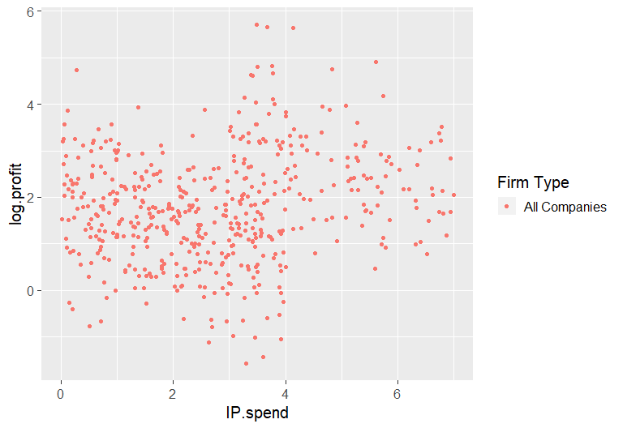

## What’s Happening?

- A graph might help

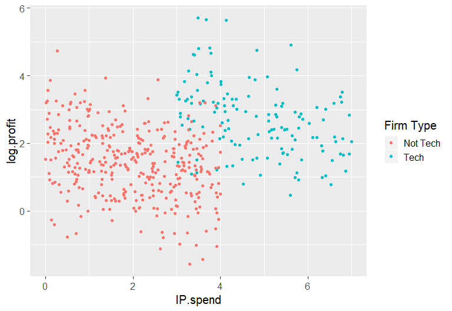

## Simpson’s Paradox

- Here we have a true negative relationship - we know it’s in the true model!
- But when we plot it out, it’s positive
- It’s clear what’s happening - WITHIN tech companies and non-tech companies, IP spend is negatively correlated with profit
- But because tech companies have higher IP spend and higher profit, they’re positively correlated!
- This is known as “Simpson’s Paradox” and shows up in many places

## Simpson’s Paradox

- So our method (looking at the correlation between them) doesn’t work!
- The simulation has shown us that we’d get it wrong if we do this, because our analysis method doesn’t correct for what tech is doing here.
- We need to have some way of incorporating what we know about tech
- Taking what we might know about the true model - that firm type has something to do with this, and adjusting so we get the right answer
- This sort of thinking is what we’ll be getting into after the midterm.

## Practice

- Use the `prob` option in `sample` to generate 300 coin flips weighted to be 55% heads. Calculate heads prop.
- Loop it 2000 times. How often will you correctly claim that the coin is more than 50% heads?
- Create `dat`: 1500 obs of `married` (0 or 1), `educ` (unif 0 to 16, plus `2*married`), `log.wage` (normal mean 5 plus `.1*educ` plus `2*married`)
- Loop it 1000 times and calculate `cor` between `educ` and `log.wage` each time.
- It’s positive - does that mean it’s right? If not, how do you know?
- Use `plot` and then `points` to plot the `married==0` and `married==1` data in different colors.

## Practice Answers

```r
co <- sample(c("Heads","Tails"),300,replace=T,prob=c(.55,.45))
mean(co=="Heads")

headsprop <- c()
for (i in 1:2000) {
  co <- sample(c("Heads","Tails"),300,replace=T,prob=c(.55,.45))
  headsprop[i] <- mean(co=="Heads")
}
mean(headsprop > .5)

educCor <- c()
for (j in 1:1000) {
  dat <- tibble(married=sample(0:1,1500,replace=T)) %>%
    mutate(educ = 2*married + runif(1500,0,16)) %>%
    mutate(log.wage = .1*educ + 2*married + rnorm(1500,5))
  educCor[j] <- cor(dat$educ,dat$log.wage)
}
mean(educCor)
#This is still wrong - we're ignoring what married does, and so OVERSTATING the correlation

plot(filter(dat,married==0)$educ,filter(dat,married==0)$log.wage,col='red',
     ylim=range(c(min(dat$log.wage),max(dat$log.wage))),
     xlim=range(c(min(dat$educ),max(dat$educ))),
     xlab="Education",
     ylab="Log Wages")
points(filter(dat,married==1)$educ,filter(dat,married==1)$log.wage,col='blue')
#Note the xlim and ylim options so we aren't cut off.
```